# Source Aggregation

Andrew L Jackson

07 June, 2019

## Create some simulated data for us to work with

This is essentially the example used in Fry, B. 2013. Alternative approaches for solving underdetermined isotope mixing problems. *MEPS*.

Here we use the package simmr to explore the two alternatives to aggregating sources in mixing models.

```r
library(simmr, quietly = TRUE)
set.seed(1)

# specify the sources
# sources <- data.frame(sources=c("A","B","C","D"),
#                         muC=c(-5,-5,5,5),sdC=c(1,1,1,1),
#                         muN=c(-5,5,5,-5),sdN=c(1,1,1,1))

# specify the source names
S_names = c("A","B","C","D")

# specify the source means
S_means = cbind(c(-5,-5,5,5), c(-5,5,5,-5))

# specify the source standard deviations
S_sds = cbind(c(1,1,1,1), c(1,1,1,1))

# speficy the consumer data at the origin
# Ten consumers for this example around 0 with small sd of error.
consumers <- cbind(dC = rnorm(10, 0, 0.1),
                   dN = rnorm(10, 0, 0.1) )

# and create the simmr object
# here we have no TDFs or concentration values
simmr_in <- simmr_load(mixtures = consumers,
                       source_names = S_names,
                       source_means = S_means,
                       source_sds = S_sds)
```

Now we can plot the data to visualise our system and the output,

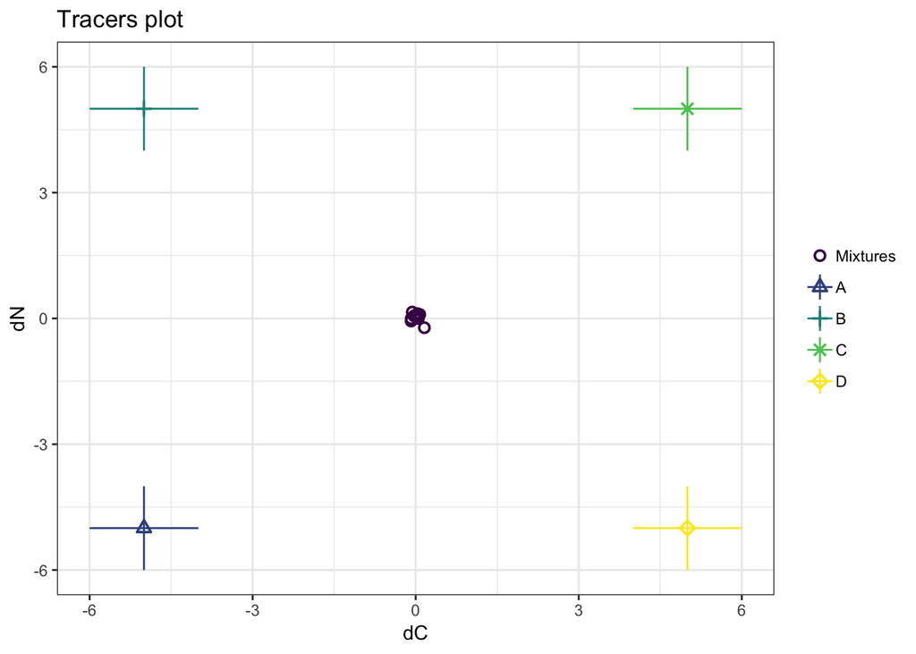

```r
plot(simmr_in)
```

## Fit the SIMM

We can fit a simmr model using the defaults, and here supress the output using the `results='hide'` option in the chunk.

```r
simmr_out = simmr_mcmc(simmr_in)
```

And we should always check for convergence.

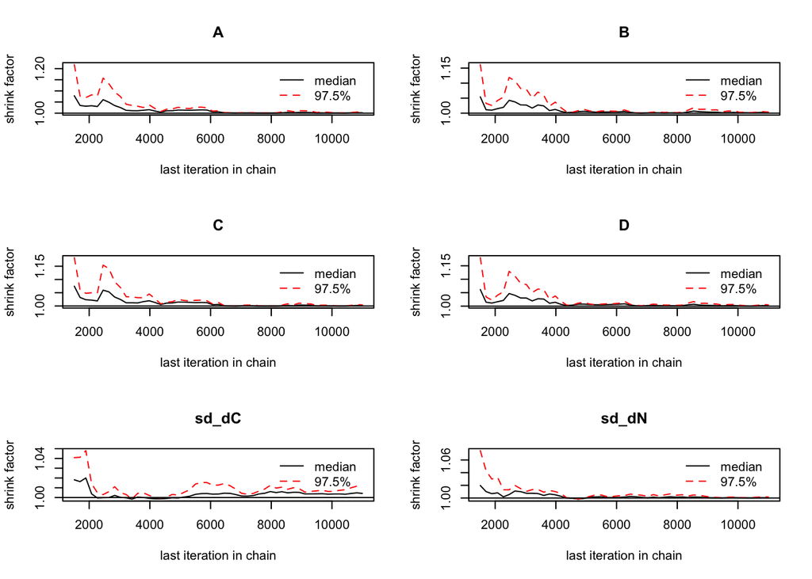

```r
# plot the convergence statistics
plot(simmr_out, type='convergence')
```

The results of this toy example are not expected to be overly helpful or meaningful.

```r
summary(simmr_out,type='statistics')
```

```
##        mean    sd
## A     0.251 0.068
## B     0.248 0.068
## C     0.254 0.069
## D     0.247 0.068
## sd_dC 0.162 0.134
## sd_dN 0.163 0.134
```

```r
summary(simmr_out,type='quantiles')
```

```
##        2.5%   25%   50%   75% 97.5%
## A     0.111 0.206 0.252 0.296 0.382
## B     0.116 0.202 0.246 0.292 0.386
## C     0.112 0.211 0.256 0.299 0.388
## D     0.116 0.202 0.245 0.291 0.390
## sd_dC 0.006 0.061 0.130 0.231 0.492
## sd_dN 0.006 0.063 0.132 0.228 0.495
```

## *A priori* aggregation

We combine the sources C and D before we run the model as is sometimes suggested. We do this by taking the mean of the means, and we square the SDs to make them variances, then add them, and then square-root them to turn them back into SDs again. We dont need to change the consumer data in any way.

```r
# specify the source names
S_names_a_priori = c("A","B","CD")

# take the mean of the last two sources C and D
S_means_a_priori = rbind(S_means[1:2,], colMeans(S_means[3:4,]) )

# square the sds for sources C and D to convert to variance,
# sum them and convert back to sd
S_sds_a_priori = rbind( S_sds[1:2,], colSums(S_sds[3:4,]^2) ^ 0.5 )

# and create the new simmr object
# here we have no TDFs or concentration values
simmr_in_a_priori <- simmr_load(mixtures = consumers,
                       source_names = S_names_a_priori,
                       source_means = S_means_a_priori,
                       source_sds = S_sds_a_priori)
```

Plot this newly combined data.

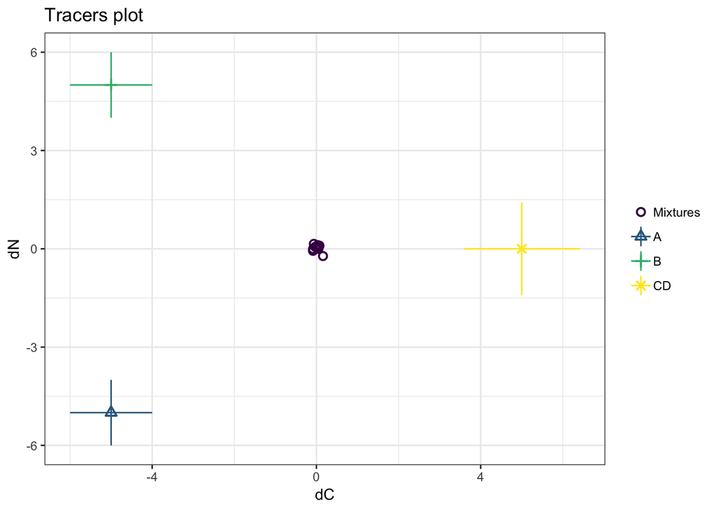

```r
# plot the raw data for the a priori aggregated example
plot(simmr_in_a_priori)
```

Run the model on the a priori combined data.

```r
# fit the a priori aggregated models
simmr_out_a_priori = simmr_mcmc(simmr_in_a_priori)
```

And plot

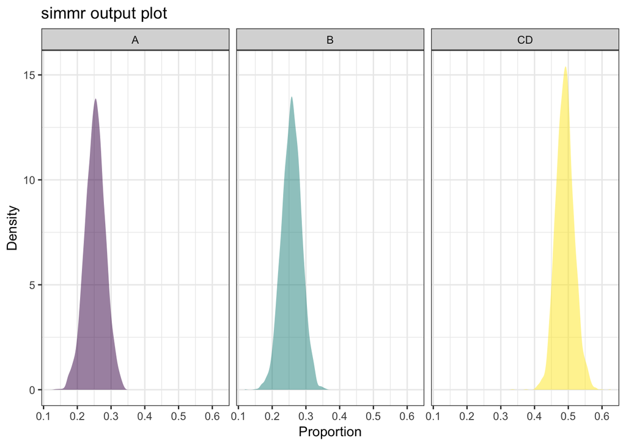

```r
# Plot the a priori aggregated diet estimatess
plot(simmr_out_a_priori, type = "density")
```

## *A posteriori* aggregation

Far more honest is to fit the model as before, with the sources as we believe them to be *a priori* and then simply add our prortions together from the posterior distribution. This is made very easy in SIMMR and also MixSIAR with dedicated functions. In fact, MixSIAR also allows easier a priori aggregation by hiding the routine outlined in the preceding section.

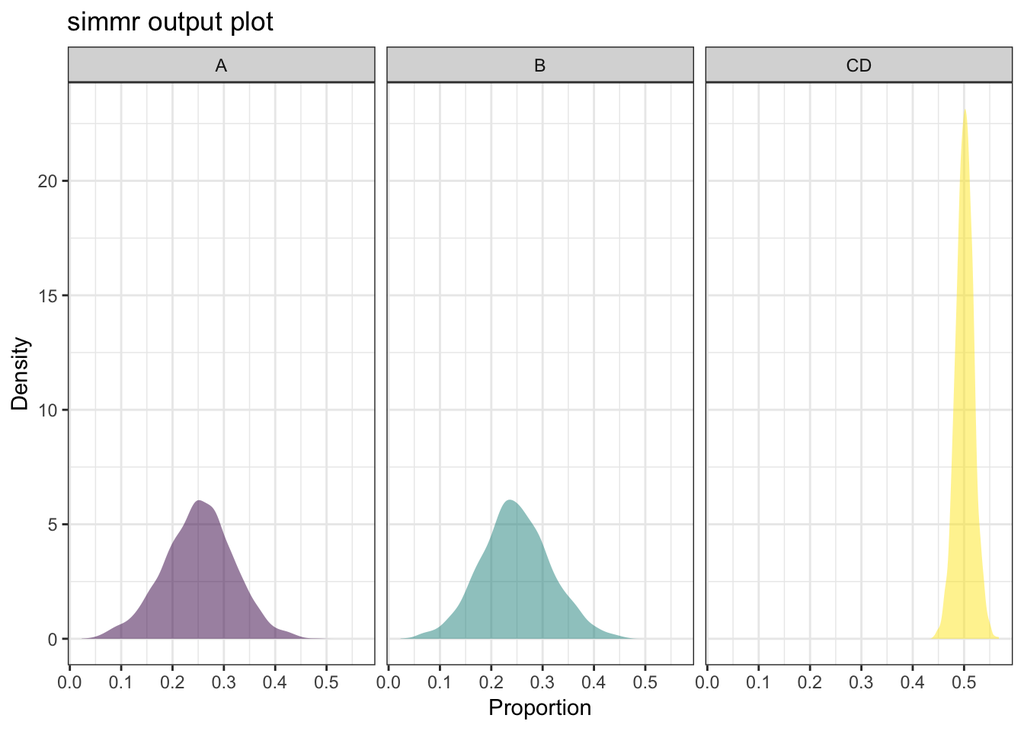

```r
# combine sources C and D which are in positions 3 and 4
simmr_out_a_posteriori <- combine_sources(
  simmr_out,
  to_combine = simmr_out$input$source_names[c(3,4)],
  new_source_name = "CD")

# Plot the a posteriori aggregated diet estimatess
plot(simmr_out_a_posteriori, type = "density")
```

This result fits much better with what we would predict: that if the model is still not sure about the contribution of the four sources to the mixture, but that it is pretty sure that on average, 50% of the diet is comprised of both C and D. This concept continues until the model is entirely certain, with no error, that the diet is wholly 100% of A+B+C+D.

One thing to experiment with here is the use of the Jeffrey’s prior of `c(0.25, 0.25, 0.25, 0.25)` in place of the default vague prior `c(1, 1, 1, 1)`. This is the nub of the criticism levelled at the SIMMs by Brett, M. 2016. Resource polygon geometry predicts Bayesian stable isotope mixing model bias. MEPS.